# Basic concepts of Statistical science

L. Porcu / C. Chilamakuri

Last modified: 01 Oct 2025

# Exercises

## Exercise 1

Suppose a ball, W, is rolled across a horizontal line of unit length [0-1]. Zero point is the starting position. We know that this ball moves at a constant speed and it is subjected to a constant frictional force. The horizontal co-ordinate of the final resting place is taken to be $\theta$.  
Please, answer the following questions:

1. Is $\theta$ a statistical model’s parameter?
2. Please, identify a reasonable statistical model generating $\theta$.
3. Please, identify the parameters of this statistical model.

A second ball is rolled in the same manner across the horizontal line repeateadly, *N* times. Each time it comes to rest to the left of W is counted a success. The total number of successes is *n*.  
Please, answer the following questions:

1. Is *n* a statistical model’s parameter?
2. Is *N* a statistical model’s parameter?
3. Please, identify a reasonable statistical model generating *n*.
4. If we know *n*, our previous statistical model generating $\theta$ has the same credibility. Is it true?

## Exercise 2

An experiment was performed to study the relationship between *X* and *Y* biomarkers.  
The relationship is visualised in the following scatter plot:

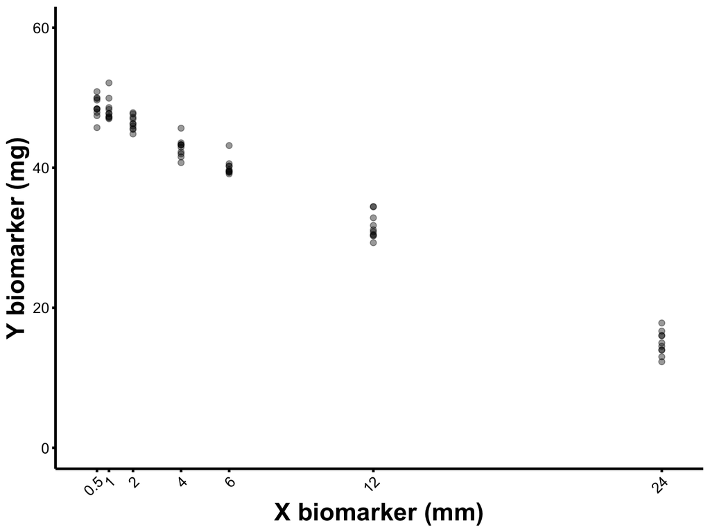

1. Could you identify a reference statistical model generating these experimental data? Please, use an equation to identify this model.
2. Please, identify systematic and random components of the model. Which are the model’s parameters?
3. Could you identify reasonable alternative statistical models generating these experimental data?
4. Suppose that also the following data has been observed:  
   - *X* biomarker = 24  
   - *Y* biomarker = 60  
   4a. Is our reference model consistent with this data? How do you call this data?  
   4b. What are the adverse effects of this point on the reference model?  
   4c. How to avoid the adverse effects of this point?
   - Suggestions:
     1. outlier’s rejection
     2. outlier’s incorporation in a new model
     3. outlier’s accomodation (i.e. reduced weight assigned to this pathological point).

## Exercise 3

Under null hypothesis (H<sub>0</sub>), a test statistic is distributed in the following manner:

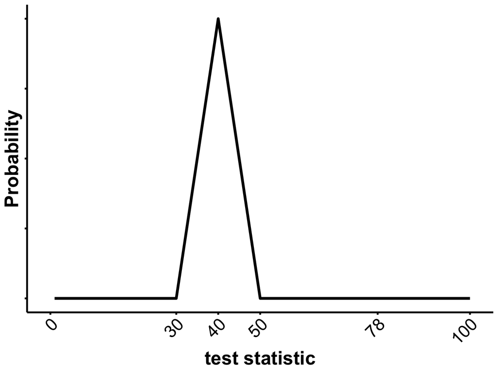

The experiment was performed. Test statistic assumed value 78.

Please, answer the following questions:

1. Based on the test result, do you reject H<sub>0</sub>?
2. Which is the probability of a false positive result (type I error)?
3. If under the alternative hypothesis H<sub>1</sub> the probability to observe a test statistic value below 50 is null, which is the probability of a type II error (i.e. null hypothesis H<sub>0</sub> is incorrectly not rejected, even though it is false)?

## Exercise 4

A coin is tossed 50 times. A binomial distribution is used as reference statistical model to analyse experimental data.

1. Please, answer the following questions:  
   1a. Identify the parameters of reference statistical model.  
   1b. Identify a reasonable test statistic.

Under null hypothesis p = 0.5, the distribution of heads is the following:

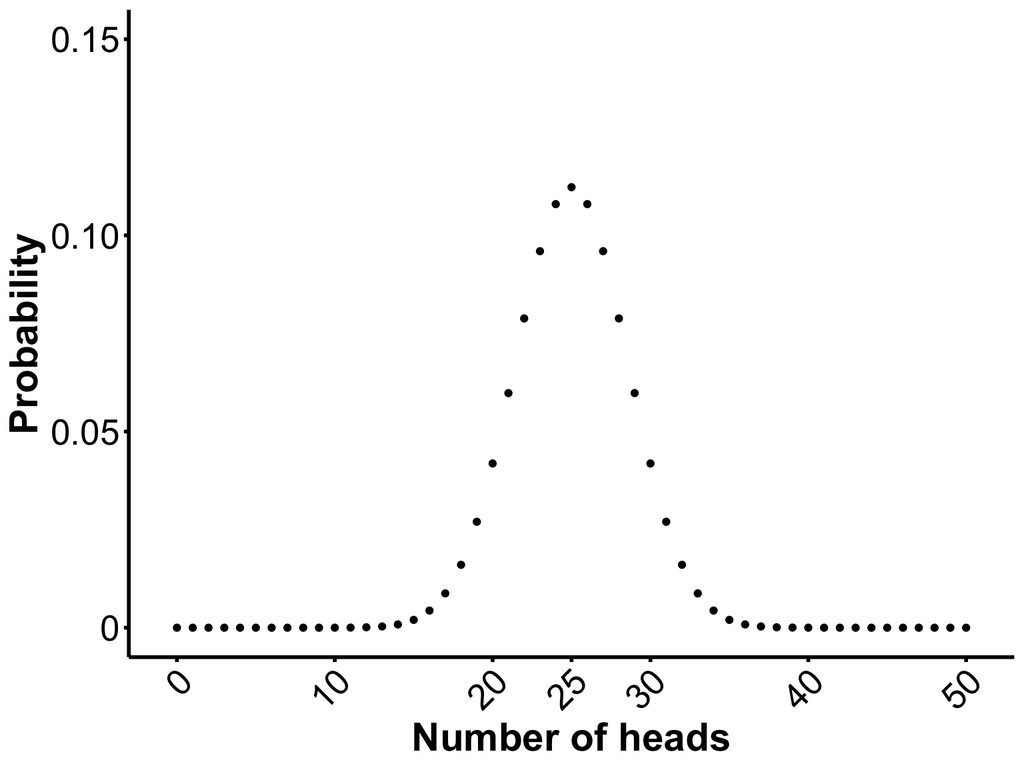

This experiment aims to demonstrate that the probability to obtain heads is higher than 0.5.

Please, answer the following questions:

2. Identify null and alternative hypotheses
3. Is the test one-tailed or two-tailed?
4. Identify qualitatively the region of significance (i.e. the set of values for a test statistic that would lead a researcher to reject the null hypothesis) at 5%
5. Please, qualitatively describe distributions of test statistic under the following simple alternative hypotheses:
- H<sub>1</sub>: p = 0.70
- H<sub>1</sub>: p = 0.80
- H<sub>1</sub>: p = 1.00

  5a. Is statistical power constant across these alternative hypotheses?  
  5b. For which alternative simple hypothesis probability of type II error (i.e. null hypothesis H<sub>0</sub> is incorrectly not rejected) is smaller?